# Learning Data Analysis

```python
# uv venv
# uv pip install pandas plotnine jupyter
# source .venv/bin/activate
# quarto check jupyter
# %pip install [pkgs]
import pandas as pd
from plotnine import *

pd
```

```
<module 'pandas' from '/Users/kanu0003/Library/Python/3.9/lib/python/site-packages/pandas/__init__.py'>
```

# Reading data file

## Text-based data (csv)

**Note**

This is how to read CSV file in python.

```python
data = pd.read_csv(
    "https://raw.githubusercontent.com/rfordatascience/tidytuesday/main/data/2025/2025-04-15/penguins.csv"
)
data
```

|  | species | island | bill_len | bill_dep | flipper_len | body_mass | sex | year |
| --- | --- | --- | --- | --- | --- | --- | --- | --- |
| 0 | Adelie | Torgersen | 39.1 | 18.7 | 181.0 | 3750.0 | male | 2007 |
| 1 | Adelie | Torgersen | 39.5 | 17.4 | 186.0 | 3800.0 | female | 2007 |
| 2 | Adelie | Torgersen | 40.3 | 18.0 | 195.0 | 3250.0 | female | 2007 |
| 3 | Adelie | Torgersen | NaN | NaN | NaN | NaN | NaN | 2007 |
| 4 | Adelie | Torgersen | 36.7 | 19.3 | 193.0 | 3450.0 | female | 2007 |
| ... | ... | ... | ... | ... | ... | ... | ... | ... |
| 339 | Chinstrap | Dream | 55.8 | 19.8 | 207.0 | 4000.0 | male | 2009 |
| 340 | Chinstrap | Dream | 43.5 | 18.1 | 202.0 | 3400.0 | female | 2009 |
| 341 | Chinstrap | Dream | 49.6 | 18.2 | 193.0 | 3775.0 | male | 2009 |
| 342 | Chinstrap | Dream | 50.8 | 19.0 | 210.0 | 4100.0 | male | 2009 |
| 343 | Chinstrap | Dream | 50.2 | 18.7 | 198.0 | 3775.0 | female | 2009 |

344 rows × 8 columns

**Note**

This is how to write a CSV file in python.

**Important**

- The reason why we set index=False is to make sure that the resulting csv file does not have a column dedicated to the row numbers.
- Note that we call the `to_csv` function from the DataFrame itself.

```python
data.to_csv("data/penguins-py.csv", index=False)
```

# Data Manipulation

## Manipulating Variables

**Note**

This is how to select variables in python.

**Important**

- It’s also possible to select columns using `iloc` but that requires us to specify columns by number
- The first `:` means that all the rows needs to be selected.

```python
data.loc[:, ["species", "island", "sex"]]
```

|  | species | island | sex |
| --- | --- | --- | --- |
| 0 | Adelie | Torgersen | male |
| 1 | Adelie | Torgersen | female |
| 2 | Adelie | Torgersen | female |
| 3 | Adelie | Torgersen | NaN |
| 4 | Adelie | Torgersen | female |
| ... | ... | ... | ... |
| 339 | Chinstrap | Dream | male |
| 340 | Chinstrap | Dream | female |
| 341 | Chinstrap | Dream | male |
| 342 | Chinstrap | Dream | male |
| 343 | Chinstrap | Dream | female |

344 rows × 3 columns

**Note**

This is how to rename variables in python.

**Important**

- While R says `rename`(*new_name* = *old_name*), python says `rename`({*old_name*:*new_name*})

```python
data.rename(columns={"body_mass": "body_mass_kg"})
```

|  | species | island | bill_len | bill_dep | flipper_len | body_mass_kg | sex | year |
| --- | --- | --- | --- | --- | --- | --- | --- | --- |
| 0 | Adelie | Torgersen | 39.1 | 18.7 | 181.0 | 3750.0 | male | 2007 |
| 1 | Adelie | Torgersen | 39.5 | 17.4 | 186.0 | 3800.0 | female | 2007 |
| 2 | Adelie | Torgersen | 40.3 | 18.0 | 195.0 | 3250.0 | female | 2007 |
| 3 | Adelie | Torgersen | NaN | NaN | NaN | NaN | NaN | 2007 |
| 4 | Adelie | Torgersen | 36.7 | 19.3 | 193.0 | 3450.0 | female | 2007 |
| ... | ... | ... | ... | ... | ... | ... | ... | ... |
| 339 | Chinstrap | Dream | 55.8 | 19.8 | 207.0 | 4000.0 | male | 2009 |
| 340 | Chinstrap | Dream | 43.5 | 18.1 | 202.0 | 3400.0 | female | 2009 |
| 341 | Chinstrap | Dream | 49.6 | 18.2 | 193.0 | 3775.0 | male | 2009 |
| 342 | Chinstrap | Dream | 50.8 | 19.0 | 210.0 | 4100.0 | male | 2009 |
| 343 | Chinstrap | Dream | 50.2 | 18.7 | 198.0 | 3775.0 | female | 2009 |

344 rows × 8 columns

**Note**

This is how to compute variables in python.

```python
data.loc[:, ["body_mass_kg"]] = data.body_mass / 1000
data
```

|  | species | island | bill_len | bill_dep | flipper_len | body_mass | sex | year | body_mass_kg |
| --- | --- | --- | --- | --- | --- | --- | --- | --- | --- |
| 0 | Adelie | Torgersen | 39.1 | 18.7 | 181.0 | 3750.0 | male | 2007 | 3.750 |
| 1 | Adelie | Torgersen | 39.5 | 17.4 | 186.0 | 3800.0 | female | 2007 | 3.800 |
| 2 | Adelie | Torgersen | 40.3 | 18.0 | 195.0 | 3250.0 | female | 2007 | 3.250 |
| 3 | Adelie | Torgersen | NaN | NaN | NaN | NaN | NaN | 2007 | NaN |
| 4 | Adelie | Torgersen | 36.7 | 19.3 | 193.0 | 3450.0 | female | 2007 | 3.450 |
| ... | ... | ... | ... | ... | ... | ... | ... | ... | ... |
| 339 | Chinstrap | Dream | 55.8 | 19.8 | 207.0 | 4000.0 | male | 2009 | 4.000 |
| 340 | Chinstrap | Dream | 43.5 | 18.1 | 202.0 | 3400.0 | female | 2009 | 3.400 |
| 341 | Chinstrap | Dream | 49.6 | 18.2 | 193.0 | 3775.0 | male | 2009 | 3.775 |
| 342 | Chinstrap | Dream | 50.8 | 19.0 | 210.0 | 4100.0 | male | 2009 | 4.100 |
| 343 | Chinstrap | Dream | 50.2 | 18.7 | 198.0 | 3775.0 | female | 2009 | 3.775 |

344 rows × 9 columns

## Manipulating Observations

**Note**

This is how you select rows in python.

```python
data[data.species == "Adelie"]
```

|  | species | island | bill_len | bill_dep | flipper_len | body_mass | sex | year | body_mass_kg |
| --- | --- | --- | --- | --- | --- | --- | --- | --- | --- |
| 0 | Adelie | Torgersen | 39.1 | 18.7 | 181.0 | 3750.0 | male | 2007 | 3.750 |
| 1 | Adelie | Torgersen | 39.5 | 17.4 | 186.0 | 3800.0 | female | 2007 | 3.800 |
| 2 | Adelie | Torgersen | 40.3 | 18.0 | 195.0 | 3250.0 | female | 2007 | 3.250 |
| 3 | Adelie | Torgersen | NaN | NaN | NaN | NaN | NaN | 2007 | NaN |
| 4 | Adelie | Torgersen | 36.7 | 19.3 | 193.0 | 3450.0 | female | 2007 | 3.450 |
| ... | ... | ... | ... | ... | ... | ... | ... | ... | ... |
| 147 | Adelie | Dream | 36.6 | 18.4 | 184.0 | 3475.0 | female | 2009 | 3.475 |
| 148 | Adelie | Dream | 36.0 | 17.8 | 195.0 | 3450.0 | female | 2009 | 3.450 |
| 149 | Adelie | Dream | 37.8 | 18.1 | 193.0 | 3750.0 | male | 2009 | 3.750 |
| 150 | Adelie | Dream | 36.0 | 17.1 | 187.0 | 3700.0 | female | 2009 | 3.700 |
| 151 | Adelie | Dream | 41.5 | 18.5 | 201.0 | 4000.0 | male | 2009 | 4.000 |

152 rows × 9 columns

**Note**

This is how to get unique rows in python.

**Important**

- Value counts will give you counts of the groups as well.
- The reset index function simply makes the resulting counts readable as a DataFrame

```python
data[["species", "island"]].value_counts().reset_index()
```

|  | species | island | count |
| --- | --- | --- | --- |
| 0 | Gentoo | Biscoe | 124 |
| 1 | Chinstrap | Dream | 68 |
| 2 | Adelie | Dream | 56 |
| 3 | Adelie | Torgersen | 52 |
| 4 | Adelie | Biscoe | 44 |

**Note**

This is how to arrange the row in python.

```python
data.sort_values(["bill_len"], ascending=False)
```

|  | species | island | bill_len | bill_dep | flipper_len | body_mass | sex | year | body_mass_kg |
| --- | --- | --- | --- | --- | --- | --- | --- | --- | --- |
| 185 | Gentoo | Biscoe | 59.6 | 17.0 | 230.0 | 6050.0 | male | 2007 | 6.05 |
| 293 | Chinstrap | Dream | 58.0 | 17.8 | 181.0 | 3700.0 | female | 2007 | 3.70 |
| 253 | Gentoo | Biscoe | 55.9 | 17.0 | 228.0 | 5600.0 | male | 2009 | 5.60 |
| 339 | Chinstrap | Dream | 55.8 | 19.8 | 207.0 | 4000.0 | male | 2009 | 4.00 |
| 267 | Gentoo | Biscoe | 55.1 | 16.0 | 230.0 | 5850.0 | male | 2009 | 5.85 |
| ... | ... | ... | ... | ... | ... | ... | ... | ... | ... |
| 70 | Adelie | Torgersen | 33.5 | 19.0 | 190.0 | 3600.0 | female | 2008 | 3.60 |
| 98 | Adelie | Dream | 33.1 | 16.1 | 178.0 | 2900.0 | female | 2008 | 2.90 |
| 142 | Adelie | Dream | 32.1 | 15.5 | 188.0 | 3050.0 | female | 2009 | 3.05 |
| 3 | Adelie | Torgersen | NaN | NaN | NaN | NaN | NaN | 2007 | NaN |
| 271 | Gentoo | Biscoe | NaN | NaN | NaN | NaN | NaN | 2009 | NaN |

344 rows × 9 columns

## Grouped operation

**Note**

This is how to group data by one or more variables in python.

**Important**

The syntax can be somewhat confusing.

- First we `group_by` using `species`.
- Then we get `body_mass` column and apply a function to that column.
- The lambda notation is similiar to the anonymous functions defined using `\(x) x > x$mean()`
- Finally we assign the resulting column to a new column.

Think about how you would do it if you want to reference a different column

```python
data["above_average_mass"] = data.groupby("species")["body_mass"].transform(
    lambda x: x > x.mean()
)
data
```

|  | species | island | bill_len | bill_dep | flipper_len | body_mass | sex | year | body_mass_kg | above_average_mass |
| --- | --- | --- | --- | --- | --- | --- | --- | --- | --- | --- |
| 0 | Adelie | Torgersen | 39.1 | 18.7 | 181.0 | 3750.0 | male | 2007 | 3.750 | True |
| 1 | Adelie | Torgersen | 39.5 | 17.4 | 186.0 | 3800.0 | female | 2007 | 3.800 | True |
| 2 | Adelie | Torgersen | 40.3 | 18.0 | 195.0 | 3250.0 | female | 2007 | 3.250 | False |
| 3 | Adelie | Torgersen | NaN | NaN | NaN | NaN | NaN | 2007 | NaN | False |
| 4 | Adelie | Torgersen | 36.7 | 19.3 | 193.0 | 3450.0 | female | 2007 | 3.450 | False |
| ... | ... | ... | ... | ... | ... | ... | ... | ... | ... | ... |
| 339 | Chinstrap | Dream | 55.8 | 19.8 | 207.0 | 4000.0 | male | 2009 | 4.000 | True |
| 340 | Chinstrap | Dream | 43.5 | 18.1 | 202.0 | 3400.0 | female | 2009 | 3.400 | False |
| 341 | Chinstrap | Dream | 49.6 | 18.2 | 193.0 | 3775.0 | male | 2009 | 3.775 | True |
| 342 | Chinstrap | Dream | 50.8 | 19.0 | 210.0 | 4100.0 | male | 2009 | 4.100 | True |
| 343 | Chinstrap | Dream | 50.2 | 18.7 | 198.0 | 3775.0 | female | 2009 | 3.775 | True |

344 rows × 10 columns

## Summarising Observations

```python
data["flipper_len"].agg(
    min_flipper="min",
    median_flipper="median",
    max_flipper="max",
)
```

```
min_flipper       172.0
median_flipper    197.0
max_flipper       231.0
Name: flipper_len, dtype: float64
```

```python
data.groupby("species")["bill_len"].mean().rename("average_bill_length").reset_index()
```

|  | species | average_bill_length |
| --- | --- | --- |
| 0 | Adelie | 38.791391 |
| 1 | Chinstrap | 48.833824 |
| 2 | Gentoo | 47.504878 |

## Joining Tables

**Note**

This is how you combine data in python.

```python
grped = data.groupby("year")
grped_dfs = [grped.get_group(x) for x in grped.groups]
data_07 = grped_dfs[0]
data_08 = grped_dfs[1]
```

```python
pd.concat([data_07, data_08])
```

|  | species | island | bill_len | bill_dep | flipper_len | body_mass | sex | year | body_mass_kg | above_average_mass |
| --- | --- | --- | --- | --- | --- | --- | --- | --- | --- | --- |
| 0 | Adelie | Torgersen | 39.1 | 18.7 | 181.0 | 3750.0 | male | 2007 | 3.75 | True |
| 1 | Adelie | Torgersen | 39.5 | 17.4 | 186.0 | 3800.0 | female | 2007 | 3.80 | True |
| 2 | Adelie | Torgersen | 40.3 | 18.0 | 195.0 | 3250.0 | female | 2007 | 3.25 | False |
| 3 | Adelie | Torgersen | NaN | NaN | NaN | NaN | NaN | 2007 | NaN | False |
| 4 | Adelie | Torgersen | 36.7 | 19.3 | 193.0 | 3450.0 | female | 2007 | 3.45 | False |
| ... | ... | ... | ... | ... | ... | ... | ... | ... | ... | ... |
| 315 | Chinstrap | Dream | 53.5 | 19.9 | 205.0 | 4500.0 | male | 2008 | 4.50 | True |
| 316 | Chinstrap | Dream | 49.0 | 19.5 | 210.0 | 3950.0 | male | 2008 | 3.95 | True |
| 317 | Chinstrap | Dream | 46.2 | 17.5 | 187.0 | 3650.0 | female | 2008 | 3.65 | False |
| 318 | Chinstrap | Dream | 50.9 | 19.1 | 196.0 | 3550.0 | male | 2008 | 3.55 | False |
| 319 | Chinstrap | Dream | 45.5 | 17.0 | 196.0 | 3500.0 | female | 2008 | 3.50 | False |

224 rows × 10 columns

**Note**

This is how to join the data in python.

```python
penguin_info = pd.DataFrame(
    {
        "species": ["Adelie", "Chinstrap", "Gentoo"],
        "scientific_name": [
            "Pygoscelis adeliae",
            "Pygoscelis antarcticus",
            "Pygoscelis papua",
        ],
        "nest_type": [
            "Nests made from stones",
            "Nests made from stones",
            "Nests lined with pebbles and vegetation",
        ],
        "conservation_status": ["Least Concern", "Least Concern", "Least Concern"],
    }
)
penguin_info
```

|  | species | scientific_name | nest_type | conservation_status |
| --- | --- | --- | --- | --- |
| 0 | Adelie | Pygoscelis adeliae | Nests made from stones | Least Concern |
| 1 | Chinstrap | Pygoscelis antarcticus | Nests made from stones | Least Concern |
| 2 | Gentoo | Pygoscelis papua | Nests lined with pebbles and vegetation | Least Concern |

```python
pd.merge(data, penguin_info, how="left", on="species")
```

|  | species | island | bill_len | bill_dep | flipper_len | body_mass | sex | year | body_mass_kg | above_average_mass | scientific_name | nest_type | conservation_status |
| --- | --- | --- | --- | --- | --- | --- | --- | --- | --- | --- | --- | --- | --- |
| 0 | Adelie | Torgersen | 39.1 | 18.7 | 181.0 | 3750.0 | male | 2007 | 3.750 | True | Pygoscelis adeliae | Nests made from stones | Least Concern |
| 1 | Adelie | Torgersen | 39.5 | 17.4 | 186.0 | 3800.0 | female | 2007 | 3.800 | True | Pygoscelis adeliae | Nests made from stones | Least Concern |
| 2 | Adelie | Torgersen | 40.3 | 18.0 | 195.0 | 3250.0 | female | 2007 | 3.250 | False | Pygoscelis adeliae | Nests made from stones | Least Concern |
| 3 | Adelie | Torgersen | NaN | NaN | NaN | NaN | NaN | 2007 | NaN | False | Pygoscelis adeliae | Nests made from stones | Least Concern |
| 4 | Adelie | Torgersen | 36.7 | 19.3 | 193.0 | 3450.0 | female | 2007 | 3.450 | False | Pygoscelis adeliae | Nests made from stones | Least Concern |
| ... | ... | ... | ... | ... | ... | ... | ... | ... | ... | ... | ... | ... | ... |
| 339 | Chinstrap | Dream | 55.8 | 19.8 | 207.0 | 4000.0 | male | 2009 | 4.000 | True | Pygoscelis antarcticus | Nests made from stones | Least Concern |
| 340 | Chinstrap | Dream | 43.5 | 18.1 | 202.0 | 3400.0 | female | 2009 | 3.400 | False | Pygoscelis antarcticus | Nests made from stones | Least Concern |
| 341 | Chinstrap | Dream | 49.6 | 18.2 | 193.0 | 3775.0 | male | 2009 | 3.775 | True | Pygoscelis antarcticus | Nests made from stones | Least Concern |
| 342 | Chinstrap | Dream | 50.8 | 19.0 | 210.0 | 4100.0 | male | 2009 | 4.100 | True | Pygoscelis antarcticus | Nests made from stones | Least Concern |
| 343 | Chinstrap | Dream | 50.2 | 18.7 | 198.0 | 3775.0 | female | 2009 | 3.775 | True | Pygoscelis antarcticus | Nests made from stones | Least Concern |

344 rows × 13 columns

# Data Visualisation

In python, we use plotnine. [Cheatsheet](https://github.com/rstudio/cheatsheets/blob/main/plotnine.pdf)

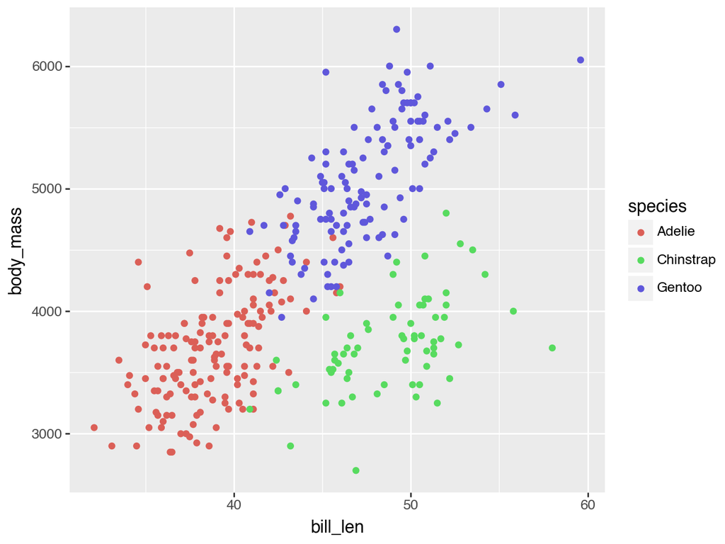

```python
(
    ggplot(data=data)
    + geom_point(mapping=aes(x="bill_len", y="body_mass", color="species"))
)
```